# DAT 301 Project 2

## Exploratory Data Analysis (EDA) — Histograms

EDA is used to understand the distribution and relationships of variables before building models.

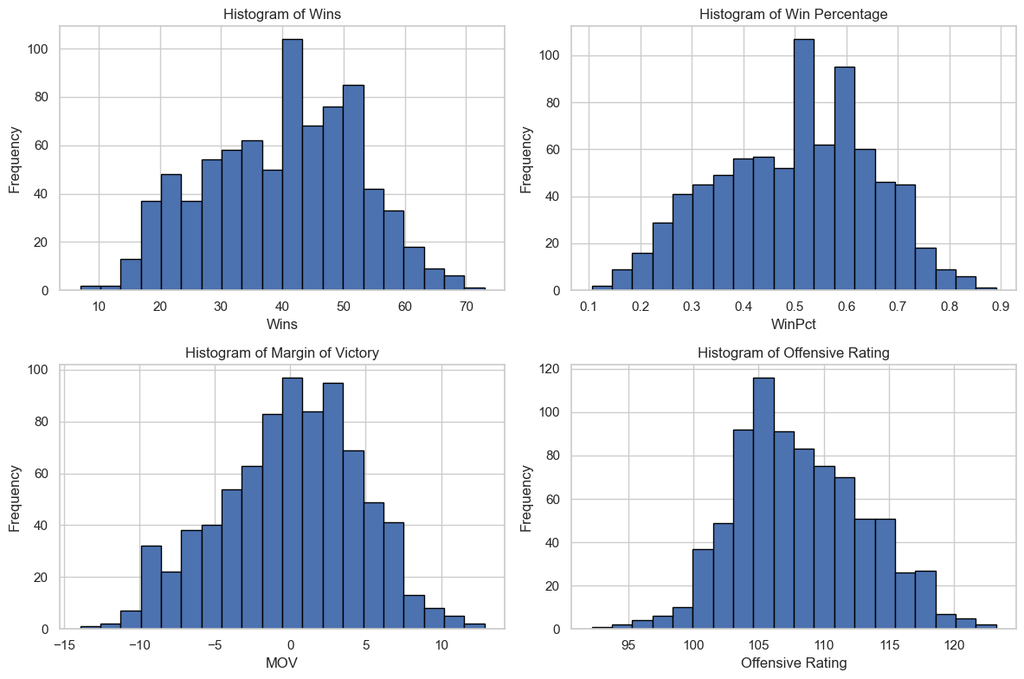

```python
fig, axes = plt.subplots(2, 2, figsize = (12, 8))

axes[0, 0].hist(nba["w"], bins = 20, edgecolor = "black")
axes[0, 0].set_title("Histogram of Wins")
axes[0, 0].set_xlabel("Wins")
axes[0, 0].set_ylabel("Frequency")

axes[0, 1].hist(nba["WinPct"], bins = 20, edgecolor = "black")
axes[0, 1].set_title("Histogram of Win Percentage")
axes[0, 1].set_xlabel("WinPct")
axes[0, 1].set_ylabel("Frequency")

axes[1, 0].hist(nba["mov"], bins = 20, edgecolor = "black")
axes[1, 0].set_title("Histogram of Margin of Victory")
axes[1, 0].set_xlabel("MOV")
axes[1, 0].set_ylabel("Frequency")

axes[1, 1].hist(nba["o_rtg"], bins = 20, edgecolor = "black")
axes[1, 1].set_title("Histogram of Offensive Rating")
axes[1, 1].set_xlabel("Offensive Rating")
axes[1, 1].set_ylabel("Frequency")

# Improve the looks
plt.tight_layout()
plt.show()
```

### Histogram Interpretations

**Histogram of Wins**: The distribution of wins appears approximately normal as it is centered around 40–45 wins. This reflects and aligns with the balanced nature of the NBA, where most teams hang around average performance, with fewer teams achieving very high or very low win totals.

**Histogram of Win Percentage**: Win percentage is also approximately normally distributed, with most teams falling between the range of 0.4 and 0.6. This indicates that the majority of teams perform near average, with relatively few extreme high-performing or low-performing teams.

**Histogram of Margin of Victory**: Margin of victory is centered around zero and shows a roughly symmetric distribution. This suggests that most teams are either slightly outscored or are slightly outscored by opponents, with only a few teams having very large positive or negative margins.

**Histogram of Offensive Rating**: These histograms show that key variables like wins and win percentage are approximately normally distributed, with most teams clustered around average performance. Margin of victory is centered near zero, indicating that most teams are relatively balanced overall. Offensive rating also shows a fairly normal distribution, suggesting that most teams fall within a similar efficiency range, with only a few extreme outliers. Basically, wins and win percentage appear relatively normally distributed, while margin of victory and offensive rating show moderate-to-no variation across teams.

Overall, in general, the distributions of wins and win percentage appear roughly centered around average team performance, which is consistent with what I found in Project 1. Margin of victory is centered near zero, and offensive rating is spread across a fairly normal range. These plots suggest that most teams cluster around average performance, while relatively few teams are extreme outliers.

## Scatterplots and Relationships with Wins

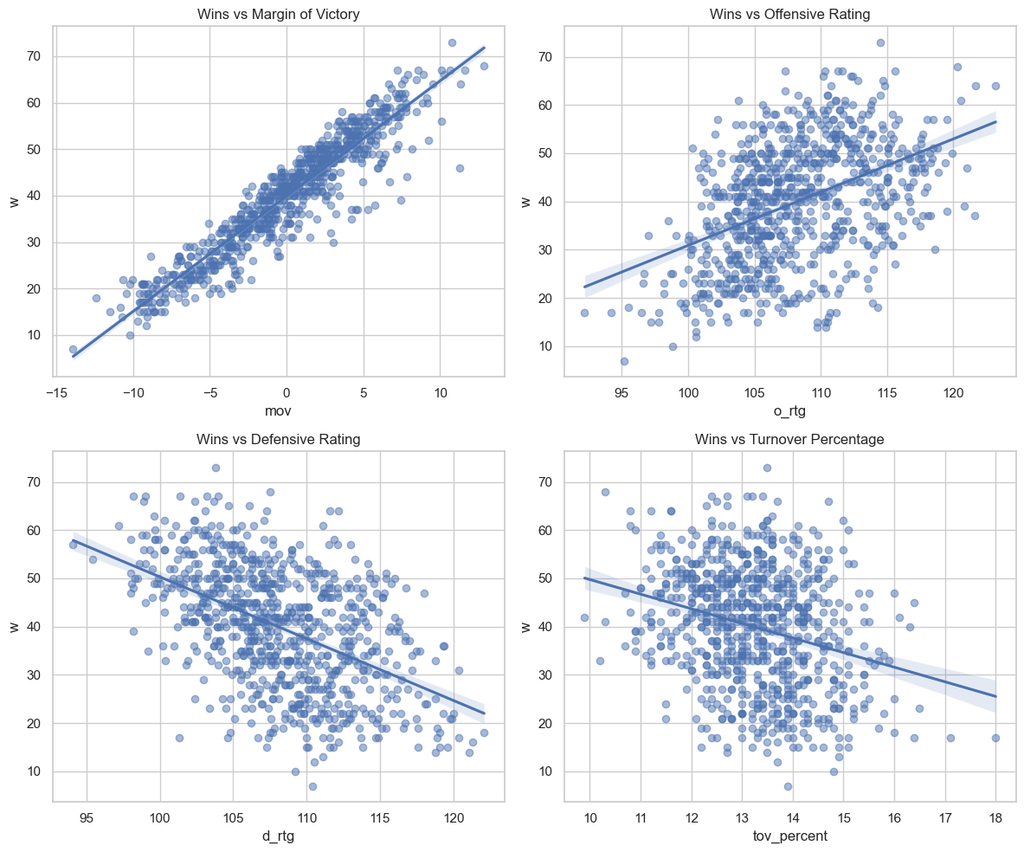

```python
fig, axes = plt.subplots(2, 2, figsize = (12, 10))

sns.regplot(data = nba, x = "mov", y = "w", ax = axes[0, 0], scatter_kws = {"alpha": 0.5})
axes[0, 0].set_title("Wins vs Margin of Victory")

sns.regplot(data = nba, x = "o_rtg", y = "w", ax = axes[0, 1], scatter_kws = {"alpha": 0.5})
axes[0, 1].set_title("Wins vs Offensive Rating")

sns.regplot(data = nba, x = "d_rtg", y="w", ax = axes[1, 0], scatter_kws = {"alpha": 0.5})
axes[1, 0].set_title("Wins vs Defensive Rating")

sns.regplot(data = nba, x = "tov_percent", y = "w", ax = axes[1, 1], scatter_kws = {"alpha": 0.5})
axes[1, 1].set_title("Wins vs Turnover Percentage")

plt.tight_layout()
plt.show()
```

# Scatterplot Interpretation

### Wins vs Margin of Victory:

There is a very strong positive linear relationship between margin of victory and wins. Teams with higher average scoring margins tend to win significantly more games, making this one of the strongest predictors of success.

### Wins vs Offensive Rating

There is a clear positive relationship between offensive rating and wins. Teams that score more efficiently tend to win more games, although the relationship is slightly more spread out compared to margin of victory.

### Wins vs Defensive Rating

There is a strong negative relationship between defensive rating and wins. Since lower defensive rating indicates better defense, this shows that teams that allow fewer points per possession tend to win more games.

### Wins vs Turnover Percentage

The relationship between turnover percentage and wins appears weaker and slightly negative. Teams that commit fewer turnovers tend to win more games, but this effect is less pronounced compared to offensive and defensive efficiency metrics.

These plots support the patterns I found in Project 1. Margin of victory and net rating show very strong positive relationships with wins. Specifically, Margin of victory shows a very strong positive linear relationship with wins, showing that teams that con- sistently outscore their opponents tend to win more games, which is expected.

Turnover percentage appears to have a weaker negative relationship with wins. Overall, efficiency metrics appear to matter a great deal in predicting team success. Overall, these scatter plots help us visualize clear relationships between variables (efficiency metrics) and wins, particularly for offensive and defensive ratings. Overall, these scatter plots help us visualize clear relationships between variables (efficiency metrics) and wins, particularly for offensive and defensive ratings.

### Additional Visualization: Net Rating vs Wins:

To further prove my point, I will include a visualization that will analyze the relationship between net rating (n_rtg) and wins. Net rating combines both offensive and defensive performance into a single metric, making ssit a strong indicator of overall team strength.

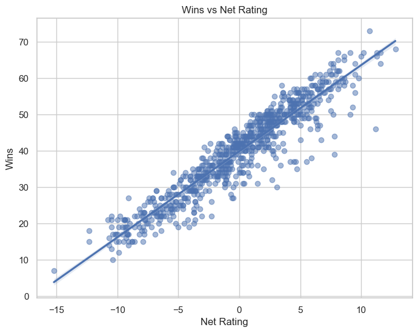

```python
plt.figure(figsize = (8, 6))
sns.regplot(data = nba, x = "n_rtg", y = "w", scatter_kws = {"alpha": 0.5})
plt.title("Wins vs Net Rating")
plt.xlabel("Net Rating")
plt.ylabel("Wins")
plt.show()
```

### Wins vs Net Rating:

This plot shows a very strong positive relationship between net rating and wins. Teams with higher net ratings consistently win more games, which reinforces the idea that overall efficiency (offense + defense combined) is one of the best predictors of team success.

## Correlation Analysis

```python
num_data = nba[[ "w", "WinPct", "mov", "o_rtg", "d_rtg",
    "n_rtg", "pace", "ts_percent", "e_fg_percent", "tov_percent"]]

corr_matrix = num_data.corr()
corr_matrix
```

|  | w | WinPct | mov | o_rtg | d_rtg | n_rtg | pace | ts_percent | e_fg_percent | tov_percent |
| --- | --- | --- | --- | --- | --- | --- | --- | --- | --- | --- |
| w | 1.000000 | 0.971604 | 0.937197 | 0.444070 | -0.497168 | 0.939364 | -0.114817 | 0.395456 | 0.351849 | -0.274656 |
| WinPct | 0.971604 | 1.000000 | 0.966534 | 0.511002 | -0.457107 | 0.968148 | -0.057429 | 0.458825 | 0.418228 | -0.303017 |
| mov | 0.937197 | 0.966534 | 1.000000 | 0.527347 | -0.471636 | 0.999025 | -0.047940 | 0.467214 | 0.425318 | -0.308081 |
| o_rtg | 0.444070 | 0.511002 | 0.527347 | 1.000000 | 0.499523 | 0.527172 | 0.569421 | 0.928964 | 0.912675 | -0.630066 |
| d_rtg | -0.497168 | -0.457107 | -0.471636 | 0.499523 | 1.000000 | -0.472812 | 0.640095 | 0.486845 | 0.512711 | -0.338106 |
| n_rtg | 0.939364 | 0.968148 | 0.999025 | 0.527172 | -0.472812 | 1.000000 | -0.048683 | 0.467353 | 0.425412 | -0.309226 |
| pace | -0.114817 | -0.057429 | -0.047940 | 0.569421 | 0.640095 | -0.048683 | 1.000000 | 0.632629 | 0.679357 | -0.381156 |
| ts_percent | 0.395456 | 0.458825 | 0.467214 | 0.928964 | 0.486845 | 0.467353 | 0.632629 | 1.000000 | 0.980872 | -0.449297 |
| e_fg_percent | 0.351849 | 0.418228 | 0.425318 | 0.912675 | 0.512711 | 0.425412 | 0.679357 | 0.980872 | 1.000000 | -0.482405 |
| tov_percent | -0.274656 | -0.303017 | -0.308081 | -0.630066 | -0.338106 | -0.309226 | -0.381156 | -0.449297 | -0.482405 | 1.000000 |

### Correlation Analysis

# Correlation Analysis Interpretation

### Correlation Analysis:

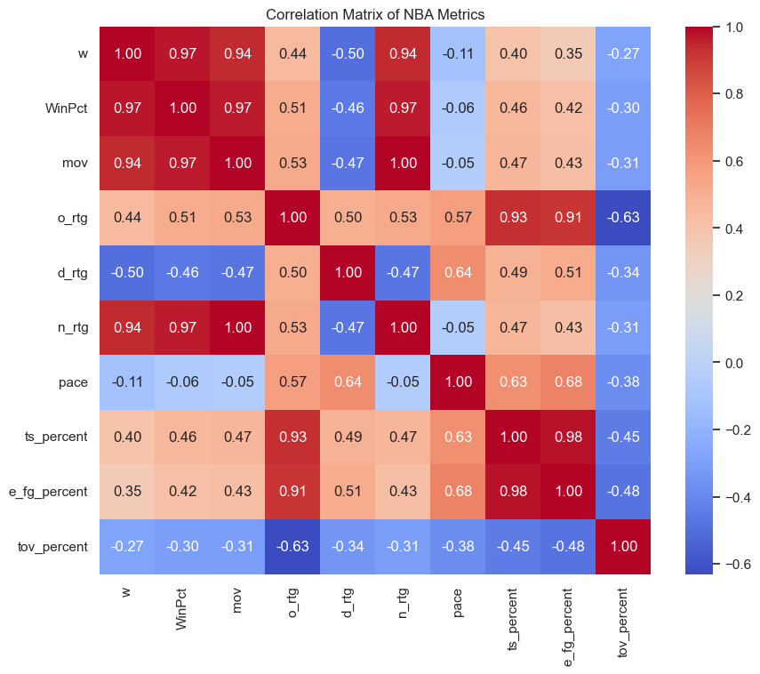

```python
plt.figure(figsize = (10, 8))
sns.heatmap(corr_matrix, annot = True, cmap = "coolwarm", fmt = ".2f")
plt.title("Correlation Matrix of NBA Metrics")
plt.show()
```

### Correlation Interpretation

The correlation matrix confirms what the scatterplots showed as it highlights the strong relationships between variables. Wins are strongly positively correlated with margin of victory and net rating, positively correlated with offensive rating, and negatively correlated with defensive rating. Pace and turnover percentage have weaker relationships with wins compared to the major efficiency metrics. Basically, strong correlations are shown between wins and efficiency metrics such as offensive rating, defensive rating, and net rating. This matches the core findings from Project 1.

## Additional Visualization Upgrade — Pairplot

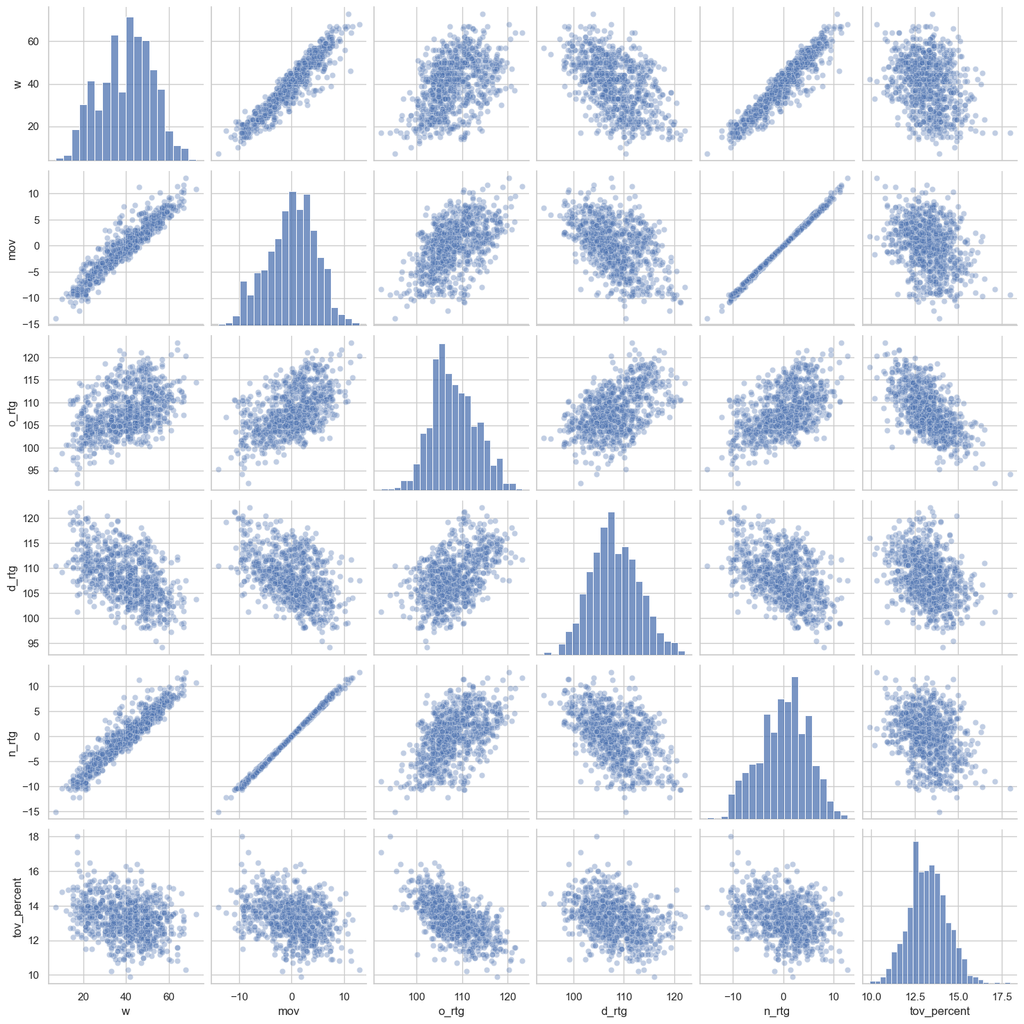

```python
sns.pairplot(
    nba[["w", "mov", "o_rtg", "d_rtg", "n_rtg", "tov_percent"]],
    diag_kind = "hist",
    plot_kws = {"alpha": 0.35}
)
plt.show()
```

### Pairplot Explanation

This pairplot was not included in my Project 1 and helps expand my analysis. This allows us to see multiple variable relationships at once and gives a broader view of the structure of the data.

## Additional Visualization Upgrade — Top 5 Teams by Net Rating

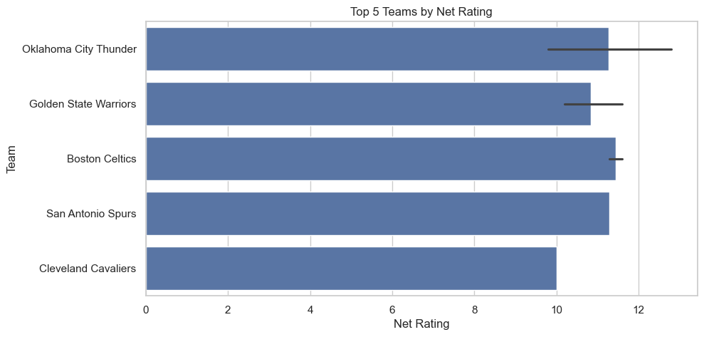

```python
top5 = nba.sort_values("n_rtg", ascending = False).head(10)

plt.figure(figsize = (10, 5))
sns.barplot(data = top5, x = "n_rtg", y = "team")
plt.title("Top 5 Teams by Net Rating")
plt.xlabel("Net Rating")
plt.ylabel("Team")
plt.show()
```

## Regression Modeling — Full Model

```python
## Added the following for some in-depth statistical analysis
model1 = smf.ols(
    "w ~ mov + o_rtg + d_rtg + n_rtg + pace + ts_percent + e_fg_percent + tov_percent",
    data=nba
).fit()

print(model1.summary())
```

```
                            OLS Regression Results
==============================================================================
Dep. Variable:                      w   R-squared:                       0.891
Model:                            OLS   Adj. R-squared:                  0.890
Method:                 Least Squares   F-statistic:                     930.2
Date:                Thu, 30 Apr 2026   Prob (F-statistic):               0.00
Time:                        17:37:31   Log-Likelihood:                -2272.4
No. Observations:                 805   AIC:                             4561.
Df Residuals:                     797   BIC:                             4598.
Df Model:                           7
Covariance Type:            nonrobust
================================================================================
                   coef    std err          t      P>|t|      [0.025      0.975]
--------------------------------------------------------------------------------
Intercept       81.4014      7.370     11.044      0.000      66.934      95.869
mov             -1.4299      0.703     -2.035      0.042      -2.809      -0.051
o_rtg            0.9257      0.238      3.888      0.000       0.458       1.393
d_rtg           -1.4103      0.225     -6.266      0.000      -1.852      -0.968
n_rtg            2.3360      0.451      5.183      0.000       1.451       3.221
pace            -0.2286      0.057     -4.024      0.000      -0.340      -0.117
ts_percent     108.8683     35.732      3.047      0.002      38.728     179.009
e_fg_percent   -33.3572     27.913     -1.195      0.232     -88.148      21.434
tov_percent     -0.7606      0.200     -3.806      0.000      -1.153      -0.368
==============================================================================
Omnibus:                      115.477   Durbin-Watson:                   1.283
Prob(Omnibus):                  0.000   Jarque-Bera (JB):              201.982
Skew:                          -0.893   Prob(JB):                     1.38e-44
Kurtosis:                       4.682   Cond. No.                     1.76e+16
==============================================================================

Notes:
[1] Standard Errors assume that the covariance matrix of the errors is correctly specified.
[2] The smallest eigenvalue is 8.42e-26. This might indicate that there are
strong multicollinearity problems or that the design matrix is singular.
```

### Full Model Notes

This full regression model includes all selected variables to evaluate their combined effect on team wins. In Project 1, the full model showed issues related to multicollinearity because net rating overlaps strongly with offensive and defensive rating. I expected a similar issue here in Python as well. This model helps identify which efficiency metrics are significant predictors before we begin simplifying the model to help us better understand and interpret the results accurately.

## Regression Modeling — Simplified Model

```python
model2 = smf.ols(
    "w ~ mov + o_rtg + d_rtg + e_fg_percent + tov_percent",
    data=nba
).fit()

print(model2.summary())
```

```
                            OLS Regression Results
==============================================================================
Dep. Variable:                      w   R-squared:                       0.887
Model:                            OLS   Adj. R-squared:                  0.887
Method:                 Least Squares   F-statistic:                     1258.
Date:                Thu, 30 Apr 2026   Prob (F-statistic):               0.00
Time:                        17:37:33   Log-Likelihood:                -2285.6
No. Observations:                 805   AIC:                             4583.
Df Residuals:                     799   BIC:                             4611.
Df Model:                           5
Covariance Type:            nonrobust
================================================================================
                   coef    std err          t      P>|t|      [0.025      0.975]
--------------------------------------------------------------------------------
Intercept       69.6716      6.853     10.167      0.000      56.220      83.124
mov             -1.5680      0.713     -2.200      0.028      -2.967      -0.169
o_rtg            3.6915      0.689      5.359      0.000       2.339       5.044
d_rtg           -3.9696      0.680     -5.835      0.000      -5.305      -2.634
e_fg_percent     9.4689     12.848      0.737      0.461     -15.752      34.690
tov_percent     -0.3412      0.177     -1.926      0.054      -0.689       0.007
==============================================================================
Omnibus:                      124.898   Durbin-Watson:                   1.257
Prob(Omnibus):                  0.000   Jarque-Bera (JB):              226.381
Skew:                          -0.941   Prob(JB):                     6.95e-50
Kurtosis:                       4.791   Cond. No.                     1.39e+04
==============================================================================

Notes:
[1] Standard Errors assume that the covariance matrix of the errors is correctly specified.
[2] The condition number is large, 1.39e+04. This might indicate that there are
strong multicollinearity or other numerical problems.
```

### Simplified Model Interpretation

This simplified model is easier to interpret while still making it an effective tool to use when making predictions. Regression models are used to determine how multiple variables can simultaneously affect wins. This simplified model makes it easier for us to interpret the data while still being able to make effective predictions. In Project 1, the simplified model explained about 88.7% of the variation in wins and showed that offensive rating and defensive rating were especially important. This Python version is intended to reproduce and confirm those main findings.

## Key Regression Findings

```python
pd.DataFrame({
    "Coefficient": model2.params,
    "P-value": model2.pvalues
})
```

|  | Coefficient | P-value |
| --- | --- | --- |
| Intercept | 69.671644 | 6.455132e-23 |
| mov | -1.568045 | 2.808894e-02 |
| o_rtg | 3.691512 | 1.094928e-07 |
| d_rtg | -3.969623 | 7.829514e-09 |
| e_fg_percent | 9.468906 | 4.613557e-01 |
| tov_percent | -0.341189 | 5.443603e-02 |

### Regression Findings Summary

Based on the simplified model:

- Offensive rating should have a strong positive relationship with wins.
- Defensive rating should have a strong negative relationship with wins.
- Margin of victory is usually significant, although its coefficient may be affected by overlap with related metrics.
- Effective field goal percentage may become less significant once offensive rating is included.
- Turnover percentage may still matter, but usually less strongly than offensive and defensive rating.

This aligns well with my Project 1 results, where offensive rating and defensive rating were the strongest predictors and the model had a very strong fit.

## Residual Analysis

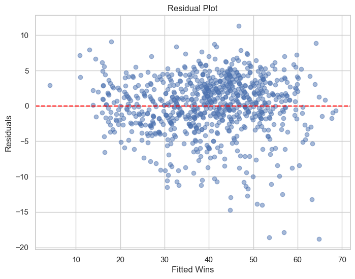

```python
plt.figure(figsize = (8, 6))
plt.scatter(model2.fittedvalues, model2.resid, alpha = 0.5)
plt.axhline(0, color = "red", linestyle = "--")
plt.title("Residual Plot")
plt.xlabel("Fitted Wins")
plt.ylabel("Residuals")
plt.show()
```

### Residual Plot Analysis

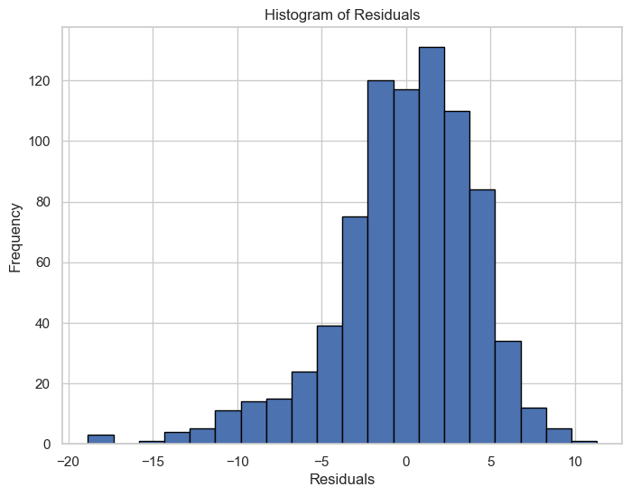

```python
plt.figure(figsize = (8, 6))
plt.hist(model2.resid, bins = 20, edgecolor = "black")
plt.title("Histogram of Residuals")
plt.xlabel("Residuals")
plt.ylabel("Frequency")
plt.show()
```

## Upgrade Section — Era Comparison

```python
nba["era"] = np.where(nba["season"] < 2015, "2000-2014", "2015+")
nba[["season", "era"]].head()
```

|  | season | era |
| --- | --- | --- |
| 0 | 2026 | 2015+ |
| 1 | 2026 | 2015+ |
| 2 | 2026 | 2015+ |
| 3 | 2026 | 2015+ |
| 4 | 2026 | 2015+ |

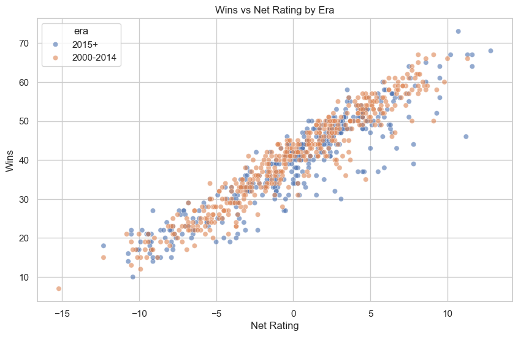

```python
plt.figure(figsize = (10, 6))
sns.scatterplot(data = nba, x = "n_rtg", y = "w", hue = "era", alpha = 0.6)
plt.title("Wins vs Net Rating by Era")
plt.xlabel("Net Rating")
plt.ylabel("Wins")
plt.show()
```

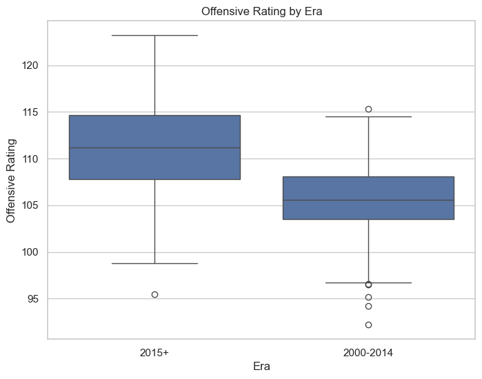

```python
plt.figure(figsize = (8, 6))
sns.boxplot(data = nba, x = "era", y = "o_rtg")
plt.title("Offensive Rating by Era")
plt.xlabel("Era")
plt.ylabel("Offensive Rating")
plt.show()
```

### Era Comparison Interpretation

I added another upgrade that extends the original project by comparing different NBA eras. the game has evolved over time, especially with faster pace and different shooting style, it is useful to see whether offensive efficiency looks different in more recent seasons.

## Results and Interpretation

The simplified regression model explains approximately **88.7%** of the variability in team wins (**R² = 0.8873**), indicating a strong fit and that the selected variables are highly predictive of team success.

**Overall Model Strength:** My model explains that approximately 88.7% of the variability in team wins, which indicates a very strong relationship between the selected efficiency metrics and overall team success. This suggests that the variables I used in this model can be highly effective when it comes to predicting wins in the NBA.

### Key Findings:

- **Offensive Rating (o_rtg)**
  - Offensive rating has a strong positive and statistically significant relationship with wins, indicating that teams with better offensive efficiency tend to win more games.
  - Coefficient: **+3.69**
  - p-value: **1.09e-07** (very significant)
- **Defensive Rating (d_rtg)**
  - Defensive rating has a strong negative and statistically significant relationship with wins.
  - Lower defensive ratings are better, which suggests that strong defense is crucial for success.
- **Margin of Victory (mov)**
  - Margin of victory is statistically significant, but its negative coefficient may be affected due to multicollinearity with other variables like offensive and defensive rating.
  - Coefficient: **-1.57**
  - p-value: **0.028**
- **Effective Field Goal Percentage (e_fg_percent)**
  - This variable is not statistically significant when other variables are included, meaning that its effect may already be captured due to the offensive rating.
  - p-value: **0.46**
- **Turnover Percentage (tov_percent)**
  - Turnover percentage shows a marginally significant negative relationship with wins, which shows that limiting turnovers may contribute to team success, even though its effects are weaker compared to the other variables.
  - p-value: **0.054**

Overall, in general, these team efficiency metrics, especially offensive and defensive ratings, are the most significant when determining team success, while individual/traditional statistics may have a smaller impact when the efficiency is already accounted for. All of these show that overall team efficiency is more important than individual/traditional statistics.

## Final Conclusion and Future Findings

The regression results support the conclusion that overall team efficiency is more important than traditional counting statistics alone. This matches the main takeaway from Project 1, where the simplified model explained about 88.7% of the variation in team wins.

This analysis demonstrates that team efficiency metrics, particularly offensive and defensive ratings, are the strongest predictors of winning in the NBA. While traditional statistics such as shooting efficiency and turnovers contribute to performance, their impact is less significant when accounting for overall team efficiency. These findings highlight the importance of advanced metrics in modern basketball analysis, which can help us evaluate basketball success and provide valuable insights into the factors that drive team success and winning outcomes in the NBA.

**Future Work**: Future research could explore how these relationships change over time or differ across different eras of basketball and the NBA.

Overall, this project 2 shows how we can use Python tools like pandas, matplotlib, seaborn, and other similar things to find predictions and trends in the field of sports analytics.

## Presentation Summary

In summary, the model explains about 89% (88.7 %) of the variation in wins, which shows a very strong relationship between team performance metrics and success. The most important factors identified were offensive rating and defensive rating, meaning that teams that score efficiently and defend well tend to win more games by a significant amount. Other variables like shooting efficiency and turnovers still play a big role, but their impact becomes less significant once overall team efficiency is taken into account.

## Sources

1. Kaggle NBA statistics dataset used for team-level NBA metrics: (https://www.kaggle.com/datasets/sumitrodatta/nba-aba-baa-stats)